# Pipeline de análise de dadoss

```r
#dev.off()
```

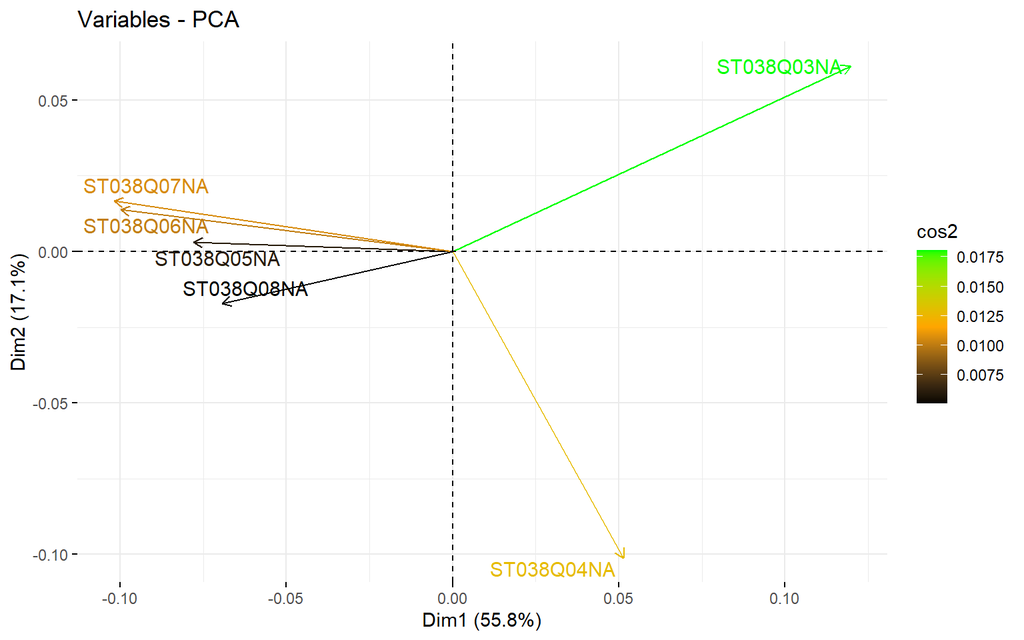

```r
#png(file="figuras/PCA/Bullyng2.png", width=600, height=350)

fviz_pca_var(data.pcabul, col.var = "cos2",
            gradient.cols = c("black", "orange", "green"),
            repel = TRUE)
```

```r
#dev.off()
```

No gráfico acima, temos as variáveis representadas nas duas compoentes principais. Quanto mais forte o tom de verde mais importante é aquela variável para a componete e maior tende a ser o valor absoluto desta variável nas componentes abaixo.

```r
data.pcabul$scores
```

```
##                 Comp.1      Comp.2       Comp.3        Comp.4        Comp.5
## ST038Q03NA  0.39090738  0.16399268  0.008668704 -0.0004843875 -0.0003855705
## ST038Q04NA  0.20622191 -0.23688678 -0.052392728  0.0056851662 -0.0167737105
## ST038Q05NA -0.13733954  0.01356771 -0.026574778  0.1331460665  0.0938627040
## ST038Q06NA -0.17124542  0.04366957 -0.139670375 -0.1399161179  0.0209886870
## ST038Q07NA -0.18960392  0.04813420 -0.006867430  0.0717109322 -0.1150342491
## ST038Q08NA -0.09894041 -0.03247739  0.216836606 -0.0701416595  0.0173421392
##                                Comp.6
## ST038Q03NA -0.00000000000000002081668
## ST038Q04NA  0.00000000000000028796410
## ST038Q05NA  0.00000000000000019081958
## ST038Q06NA  0.00000000000000010234869
## ST038Q07NA  0.00000000000000001908196
## ST038Q08NA  0.00000000000000011102230
```

```r
modBul = grm(bul)

coef(modBul)
```

```
##            Extrmt1 Extrmt2 Extrmt3 Dscrmn
## ST038Q03NA   0.818   1.890   2.653  1.986
## ST038Q04NA   0.664   1.685   2.447  2.472
## ST038Q05NA   1.255   1.842   2.621  3.509
## ST038Q06NA   1.178   1.806   2.668  3.016
## ST038Q07NA   1.353   1.884   2.591  3.509
## ST038Q08NA   0.893   1.433   2.115  3.182
```

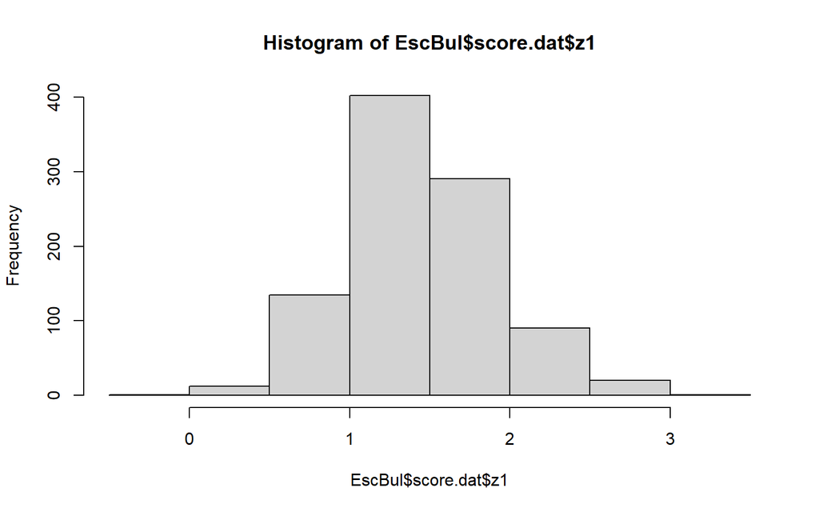

```r
EscBul = factor.scores(modBul)

#Invertendo os indicadores
#EscBul$score.dat$z1 = EscBul$score.dat$z1 * -1


hist(EscBul$score.dat$z1)
```

```r
df_pisa = EscBul$score.dat %>%
dplyr::select(-Obs, -Exp, -se.z1) %>%
mutate_at(vars(starts_with("ST")), factor) %>%
mutate_at(vars(starts_with("PA")), factor) %>%
mutate_at(vars(starts_with("SC")), factor) %>%
rename("Bullying" = z1) %>%
mutate(Bullying_Z = scale(Bullying)[,1]) %>%
right_join(df_pisa)
```

```r
# df_pisa %>%
#   dplyr::select(bullyng, ST038Q03NA) %>%
#   ggplot(aes(x = bullyng, fill = factor(ST038Q03NA)))+geom_density(alpha = 0.5)
```

## Indisciplina

Selecionando apenas as variáveis de indisciplina

```r
ind = df_pisa %>%
  dplyr::select(ST097Q01TA,ST097Q02TA,ST097Q03TA,ST097Q04TA,ST097Q05TA)


corind = hetcor(ind)

#Matrix de correlacao policorica de indisciplina

corind = corind$correlations
```

```r
png(file="figuras/cor_policoricas/Indisciplina.png", width=600, height=350)


corrplot(corind, type="upper", order="hclust",
         col=brewer.pal(n=8, name="RdYlBu"), diag = F)

#dev.off()
```

```r
data.pcaind <- princomp(corind)
summary(data.pcaind)
```

```
## Importance of components:
##                           Comp.1    Comp.2    Comp.3    Comp.4
## Standard deviation     0.2852717 0.1940557 0.1917321 0.1396196
## Proportion of Variance 0.4642526 0.2148274 0.2097137 0.1112063
## Cumulative Proportion  0.4642526 0.6790800 0.8887937 1.0000000
##                                           Comp.5
## Standard deviation     0.00000000147500160691113
## Proportion of Variance 0.00000000000000001241143
## Cumulative Proportion  0.99999999999999988897770
```

```r
eigen(corind)
```

```
## eigen() decomposition
## $values
## [1] 3.2142216 0.6185175 0.4337653 0.4214553 0.3120403
##
## $vectors
##            [,1]       [,2]       [,3]       [,4]        [,5]
## [1,] -0.4455047  0.3626755 -0.3755338  0.7055859  0.17639425
## [2,] -0.4698049  0.3264336  0.3346209 -0.1008255 -0.74201584
## [3,] -0.4675326  0.2378757  0.4354946 -0.3467254  0.64416959
## [4,] -0.4489347 -0.2273683 -0.6885878 -0.5191316 -0.05577111
## [5,] -0.4008488 -0.8084716  0.2884346  0.3197916 -0.01525371
```

```r
png(file="figuras/PCA/Indisciplina1.png", width=600, height=350)

fviz_cos2(data.pcaind, choice = "var", axes = 1:2)

#dev.off()
```

```r
png(file="figuras/PCA/Indisciplina2.png", width=600, height=350)

fviz_pca_var(data.pcaind, col.var = "cos2",
            gradient.cols = c("black", "orange", "green"),
            repel = TRUE)
#dev.off()
```

```r
data.pcaind$scores
```

```
##                Comp.1     Comp.2      Comp.3       Comp.4
## ST097Q01TA  0.2172673  0.2034256  0.28288357  0.053019834
## ST097Q02TA  0.2300942 -0.1495197 -0.02311449 -0.231163301
## ST097Q03TA  0.1782223 -0.2063889 -0.11836907  0.202202774
## ST097Q04TA -0.1136552  0.2637622 -0.26974827 -0.016782016
## ST097Q05TA -0.5119284 -0.1112791  0.12834827 -0.007277291
##                                Comp.5
## ST097Q01TA -0.00000000000000020816682
## ST097Q02TA  0.00000000000000001387779
## ST097Q03TA -0.00000000000000012490009
## ST097Q04TA -0.00000000000000004857226
## ST097Q05TA  0.00000000000000005551115
```

```r
modInd = grm(ind)
coef(modInd)
```

```
##            Extrmt1 Extrmt2 Extrmt3 Dscrmn
## ST097Q01TA  -1.464  -0.318   1.389  2.042
## ST097Q02TA  -1.088  -0.154   1.352  2.620
## ST097Q03TA  -1.216  -0.263   0.983  2.512
## ST097Q04TA  -1.747  -0.676   0.722  1.973
## ST097Q05TA  -1.361  -0.194   1.205  1.443
```

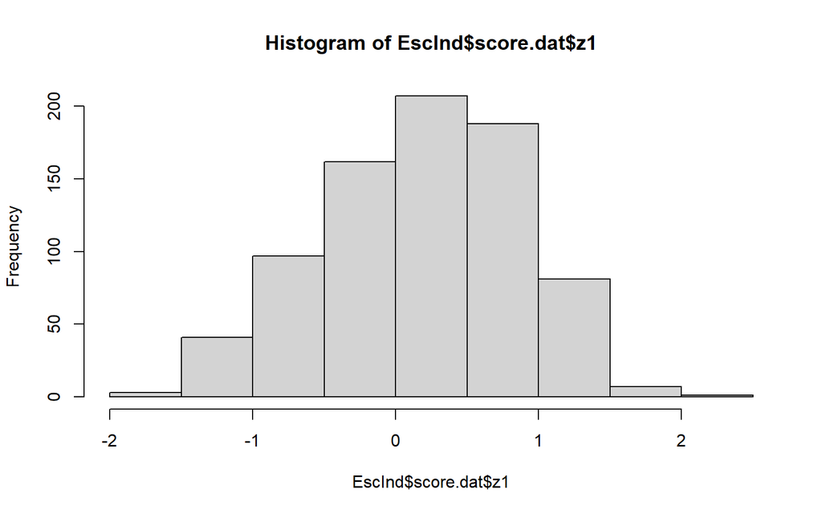

```r
EscInd = factor.scores(modInd)


EscInd$score.dat$z1 = EscInd$score.dat$z1 * -1


hist(EscInd$score.dat$z1)
```

```r
names(modInd)
```

```
##  [1] "coefficients" "log.Lik"      "convergence"  "hessian"      "counts"
##  [6] "patterns"     "GH"           "max.sc"       "constrained"  "IRT.param"
## [11] "X"            "control"      "na.action"    "call"
```

```r
summary(modInd)
```

```
##
## Call:
## grm(data = ind)
##
## Model Summary:
##    log.Lik      AIC      BIC
##  -60449.29 120938.6 121084.1
##
## Coefficients:
## $ST097Q01TA
##          value
## Extrmt1 -1.464
## Extrmt2 -0.318
## Extrmt3  1.389
## Dscrmn   2.042
##
## $ST097Q02TA
##          value
## Extrmt1 -1.088
## Extrmt2 -0.154
## Extrmt3  1.352
## Dscrmn   2.620
##
## $ST097Q03TA
##          value
## Extrmt1 -1.216
## Extrmt2 -0.263
## Extrmt3  0.983
## Dscrmn   2.512
##
## $ST097Q04TA
##          value
## Extrmt1 -1.747
## Extrmt2 -0.676
## Extrmt3  0.722
## Dscrmn   1.973
##
## $ST097Q05TA
##          value
## Extrmt1 -1.361
## Extrmt2 -0.194
## Extrmt3  1.205
## Dscrmn   1.443
##
##
## Integration:
## method: Gauss-Hermite
## quadrature points: 21
##
## Optimization:
## Convergence: 0
## max(|grad|): 0.51
## quasi-Newton: BFGS
```

```r
png(file="figuras/TRI/Indisciplina_ST097Q01TA.png", width=600, height=350)
plot(modInd, item=1,lwd = 2,main = "ST097Q01TA", xlab="Indisciplina",ylab="Probability")
#dev.off()

png(file="figuras/TRI/Indisciplina_ST097Q02TA.png", width=600, height=350)
plot(modInd, item=2,lwd = 2,main = "ST097Q02TA", xlab="Indisciplina",ylab="Probability")
#dev.off()

png(file="figuras/TRI/Indisciplina_ST097Q03TA.png", width=600, height=350)
plot(modInd, item=3,lwd = 2,main = "ST097Q03TA", xlab="Indisciplina",ylab="Probability")
#dev.off()

png(file="figuras/TRI/Indisciplina_ST097Q04TA.png", width=600, height=350)
plot(modInd, item=4,lwd = 2,main = "ST097Q04TA", xlab="Indisciplina",ylab="Probability")
#dev.off()

png(file="figuras/TRI/Indisciplina_ST097Q05TA.png", width=600, height=350)
plot(modInd, item=5,lwd = 2,main = "ST097Q05TA", xlab="Indisciplina",ylab="Probability")
#dev.off()
```

O codigo abaixo inclui a variavel de indisciplina no banco de dados final, df_pisa.

```r
df_pisa = EscInd$score.dat %>%
  dplyr::select(-Obs, -Exp, -se.z1)%>%
  mutate_at(vars(starts_with("ST")), factor) %>%
  mutate_at(vars(starts_with("PA")), factor) %>%
  mutate_at(vars(starts_with("SC")), factor) %>%
  rename("indisciplina" = z1) %>%
  mutate(indisciplina_Z = scale(indisciplina)[,1]) %>%
  right_join(df_pisa)
```

#Falta e atraso

Selecionando apenas as variáveis de falta e atraso.

```r
fea = df_pisa %>%
  dplyr::select(ST062Q01TA,ST062Q02TA,ST062Q03TA)


corfea = hetcor(fea)

#Matrix de correlacao policorica de falta e atraso
corfea = corfea$correlations
```

```r
png(file="figuras/cor_policoricas/Falta_atraso.png", width=600, height=350)


corrplot(corfea, type="upper", order="hclust",
         col=brewer.pal(n=8, name="RdYlBu"), diag = F)

#dev.off()
```

```r
data.pcafea <- princomp(corfea)
summary(data.pcafea)
```

```
## Importance of components:
##                           Comp.1    Comp.2                   Comp.3
## Standard deviation     0.4389097 0.2263019 0.0000000105367121277235
## Proportion of Variance 0.7899871 0.2100129 0.0000000000000004552813
## Cumulative Proportion  0.7899871 1.0000000 1.0000000000000000000000
```

```r
eigen(corfea)
```

```
## eigen() decomposition
## $values
## [1] 1.8749566 0.7401842 0.3848593
##
## $vectors
##            [,1]       [,2]       [,3]
## [1,] -0.6004582 -0.4681844  0.6482695
## [2,] -0.6338225 -0.2156378 -0.7428118
## [3,] -0.4875643  0.8569152  0.1672643
```

```r
png(file="figuras/PCA/Falta_atraso1.png", width=600, height=350)

fviz_cos2(data.pcafea, choice = "var", axes = 1:2)

#dev.off()
```

```r
png(file="figuras/PCA/Falta_atraso2.png", width=600, height=350)

fviz_pca_var(data.pcafea, col.var = "cos2",
            gradient.cols = c("black", "orange", "green"),
            repel = TRUE)

#dev.off()
```

```r
data.pcafea$scores
```

```
##                Comp.1      Comp.2                    Comp.3
## ST062Q01TA  0.3857400  0.25073655  0.0000000000000005828671
## ST062Q02TA  0.2282785 -0.29761001 -0.0000000000000006800116
## ST062Q03TA -0.6140185  0.04687347  0.0000000000000002775558
```

```r
modFea = grm(fea)
coef(modFea)
```

```
##            Extrmt1 Extrmt2 Extrmt3 Dscrmn
## ST062Q01TA   0.151   1.779   2.349  1.639
## ST062Q02TA   0.054   1.439   2.019  3.613
## ST062Q03TA   0.308   2.655   3.629  0.839
```

```r
EscFea = factor.scores(modFea)
```

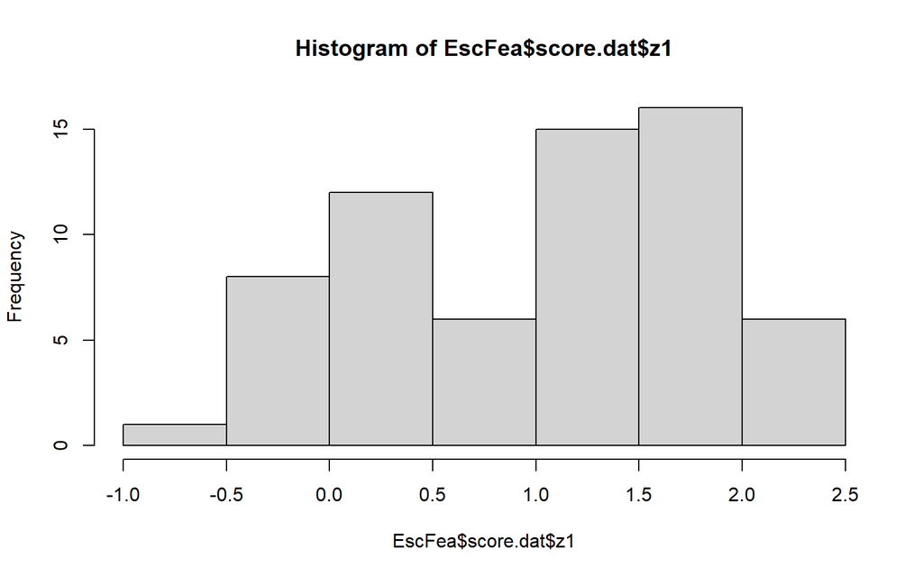

```r
#EscFea$score.dat$z1 = EscFea$score.dat$z1 * -1


hist(EscFea$score.dat$z1)
```

```r
names(modFea)
```

```
##  [1] "coefficients" "log.Lik"      "convergence"  "hessian"      "counts"
##  [6] "patterns"     "GH"           "max.sc"       "constrained"  "IRT.param"
## [11] "X"            "control"      "na.action"    "call"
```

```r
summary(modFea)
```

```
##
## Call:
## grm(data = fea)
##
## Model Summary:
##    log.Lik      AIC      BIC
##  -30588.75 61201.49 61288.82
##
## Coefficients:
## $ST062Q01TA
##         value
## Extrmt1 0.151
## Extrmt2 1.779
## Extrmt3 2.349
## Dscrmn  1.639
##
## $ST062Q02TA
##         value
## Extrmt1 0.054
## Extrmt2 1.439
## Extrmt3 2.019
## Dscrmn  3.613
##
## $ST062Q03TA
##         value
## Extrmt1 0.308
## Extrmt2 2.655
## Extrmt3 3.629
## Dscrmn  0.839
##
##
## Integration:
## method: Gauss-Hermite
## quadrature points: 21
##
## Optimization:
## Convergence: 0
## max(|grad|): 0.022
## quasi-Newton: BFGS
```

```r
png(file="figuras/TRI/falta_atraso_ST062Q01TA.png", width=600, height=350)
plot(modFea, item=1,lwd = 2,main = "ST062Q01TA", xlab="Falta e atraso",ylab="Probability")
#dev.off()

png(file="figuras/TRI/falta_atraso_ST062Q02TA.png", width=600, height=350)
plot(modFea, item=2,lwd = 2,main = "ST062Q02TA", xlab="Falta e atraso",ylab="Probability")
#dev.off()

png(file="figuras/TRI/falta_atraso_ST062Q03TA.png", width=600, height=350)
plot(modFea, item=3,lwd = 2,main = "ST062Q03TA", xlab="Falta e atraso",ylab="Probability")
#dev.off()
```

O codigo abaixo inclui a variavel de falta e atraso no banco de dados final, df_pisa.

```r
df_pisa = EscFea$score.dat %>%
  dplyr::select(-Obs, -Exp, -se.z1) %>%
  mutate_at(vars(starts_with("ST")), factor) %>%
  mutate_at(vars(starts_with("PA")), factor) %>%
  mutate_at(vars(starts_with("SC")), factor)%>%
  rename("faltaeatraso" = z1) %>%
  mutate(faltaeatraso_Z = scale(faltaeatraso)[,1]) %>%
  right_join(df_pisa)
```

## Entusiasmo docente

Selecionando apenas as variáveis de entusiasmo docente

```r
ent = df_pisa %>%
  dplyr::select(ST213Q01HA,ST213Q02HA,ST213Q03HA,ST213Q04HA)


corent = hetcor(ent)

#Matrix de correlacao policorica de entusiasmo docente
corent = corent$correlations
```

```r
png(file="figuras/cor_policoricas/Entusiasmo_docente.png", width=600, height=350)


corrplot(corent, type="upper", order="hclust",
         col=brewer.pal(n=8, name="RdYlBu"), diag = F)

#dev.off()
```

```r
data.pcaent <- princomp(corent)
summary(data.pcaent)
```

```
## Importance of components:
##                           Comp.1    Comp.2    Comp.3                   Comp.4
## Standard deviation     0.1782342 0.1420656 0.1228980 0.0000000052683560638618
## Proportion of Variance 0.4737590 0.3009907 0.2252503 0.0000000000000004139289
## Cumulative Proportion  0.4737590 0.7747497 1.0000000 1.0000000000000000000000
```

```r
eigen(corent)
```

```
## eigen() decomposition
## $values
## [1] 3.1181443 0.3544581 0.2837202 0.2436775
##
## $vectors
##            [,1]       [,2]       [,3]       [,4]
## [1,] -0.5028362 -0.0260371  0.8576639 -0.1043576
## [2,] -0.4872091 -0.7930041 -0.3291278 -0.1595203
## [3,] -0.4992705  0.5625840 -0.3440220 -0.5620294
## [4,] -0.5104038  0.2323054 -0.1942586  0.8048514
```

```r
png(file="figuras/PCA/Entusiasmo_docente1.png", width=600, height=350)

fviz_cos2(data.pcaent, choice = "var", axes = 1:2)

#dev.off()
```

```r
png(file="figuras/PCA/Entusiasmo_docente2.png", width=600, height=350)

fviz_pca_var(data.pcaent, col.var = "cos2",
            gradient.cols = c("black", "orange", "green"),
            repel = TRUE)
#dev.off()
```

```r
data.pcaent$scores
```

```
##                  Comp.1      Comp.2      Comp.3                      Comp.4
## ST213Q01HA -0.003969091  0.24370246  0.02929757  0.000000000000000163064007
## ST213Q02HA -0.282947319 -0.09096277  0.03248451 -0.000000000000000006938894
## ST213Q03HA  0.197468466 -0.10283365  0.13732548 -0.000000000000000100613962
## ST213Q04HA  0.089447944 -0.04990604 -0.19910756 -0.000000000000000055511151
```

```r
modEnt = grm(ent)
coef(modEnt)
```

```
##            Extrmt1 Extrmt2 Extrmt3 Dscrmn
## ST213Q01HA  -1.887  -1.153   0.656  3.030
## ST213Q02HA  -1.691  -0.416   1.177  2.452
## ST213Q03HA  -2.064  -1.261   0.762  3.004
## ST213Q04HA  -1.887  -1.028   0.652  3.619
```

```r
EscEnt = factor.scores(modEnt)
```

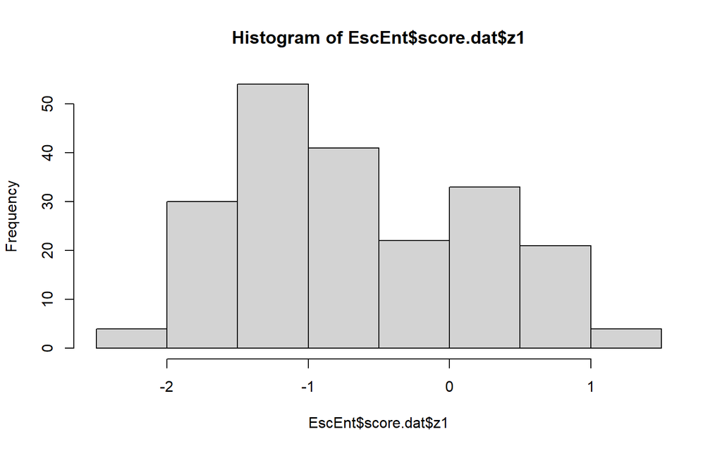

```r
hist(EscEnt$score.dat$z1)
```

```r
names(modEnt)
```

```
##  [1] "coefficients" "log.Lik"      "convergence"  "hessian"      "counts"
##  [6] "patterns"     "GH"           "max.sc"       "constrained"  "IRT.param"
## [11] "X"            "control"      "na.action"    "call"
```

```r
summary(modEnt)
```

```
##
## Call:
## grm(data = ent)
##
## Model Summary:
##    log.Lik      AIC      BIC
##  -36810.86 73653.73 73770.16
##
## Coefficients:
## $ST213Q01HA
##          value
## Extrmt1 -1.887
## Extrmt2 -1.153
## Extrmt3  0.656
## Dscrmn   3.030
##
## $ST213Q02HA
##          value
## Extrmt1 -1.691
## Extrmt2 -0.416
## Extrmt3  1.177
## Dscrmn   2.452
##
## $ST213Q03HA
##          value
## Extrmt1 -2.064
## Extrmt2 -1.261
## Extrmt3  0.762
## Dscrmn   3.004
##
## $ST213Q04HA
##          value
## Extrmt1 -1.887
## Extrmt2 -1.028
## Extrmt3  0.652
## Dscrmn   3.619
##
##
## Integration:
## method: Gauss-Hermite
## quadrature points: 21
##
## Optimization:
## Convergence: 0
## max(|grad|): 3.5
## quasi-Newton: BFGS
```

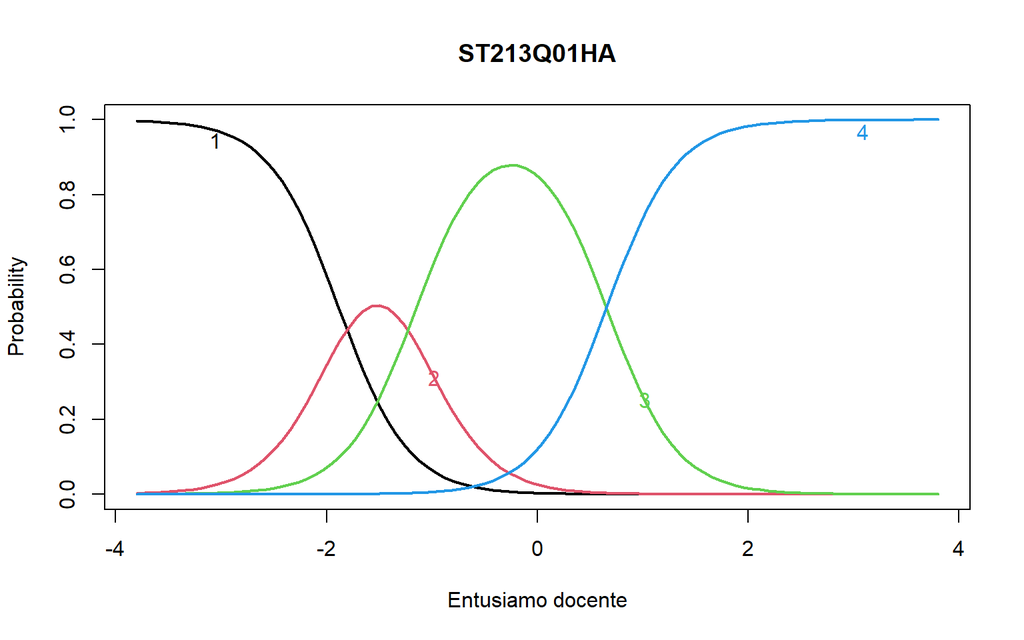

```r
#png(file="figuras/TRI/Entusiamo_ST213Q01HA.png", width=600, height=350)
plot(modEnt, item=1,lwd = 2,main = "ST213Q01HA", xlab="Entusiamo docente",ylab="Probability")
```

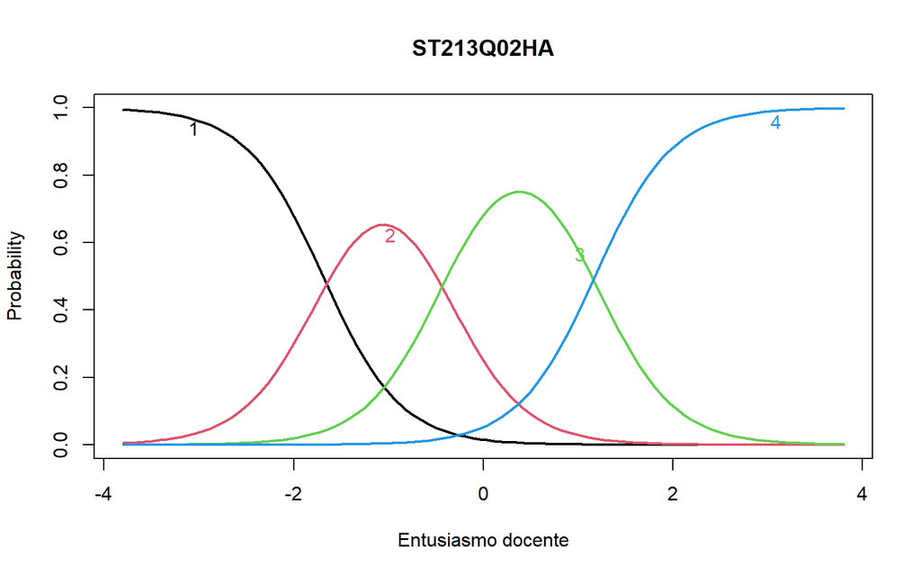

```r
#dev.off()

#png(file="figuras/TRI/Entusiamo_ST213Q02HA.png", width=600, height=350)
plot(modEnt, item=2,lwd = 2,main = "ST213Q02HA", xlab="Entusiasmo docente",ylab="Probability")
```

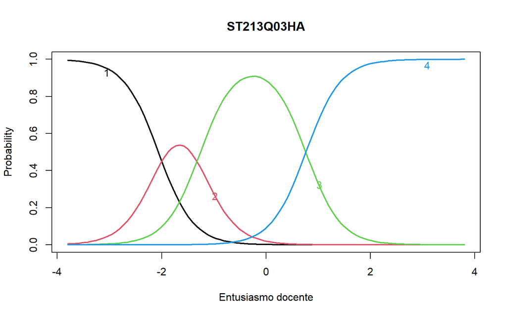

```r
#dev.off()

#png(file="figuras/TRI/Entusiamo_ST213Q03HA.png", width=600, height=350)
plot(modEnt, item=3,lwd = 2,main = "ST213Q03HA", xlab="Entusiasmo docente",ylab="Probability")
```

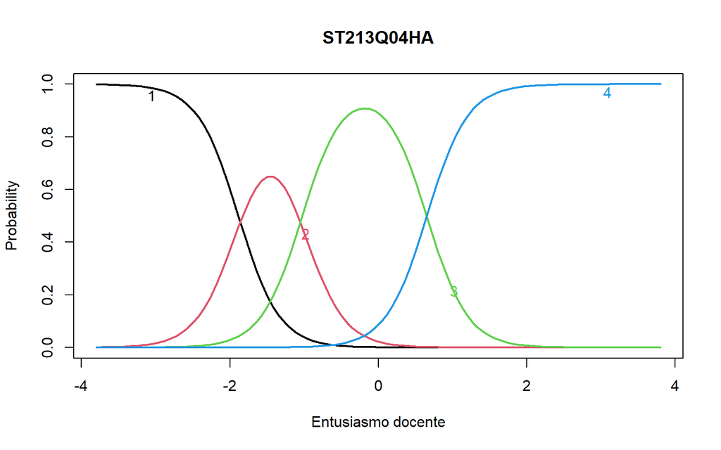

```r
#dev.off()

#png(file="figuras/TRI/Entusiamo_ST213Q04HA.png", width=600, height=350)
plot(modEnt, item=4,lwd = 2,main = "ST213Q04HA", xlab="Entusiasmo docente",ylab="Probability")
```

```r
#dev.off()
```

```r
df_pisa = EscEnt$score.dat %>%
  dplyr::select(-Obs, -Exp, -se.z1) %>%
  mutate_at(vars(starts_with("ST")), factor) %>%
  mutate_at(vars(starts_with("PA")), factor) %>%
  mutate_at(vars(starts_with("SC")), factor)%>%
  rename("Entusiasmo" = z1) %>%
  mutate(Entusiasmo_Z = scale(Entusiasmo)[,1]) %>%
  right_join(df_pisa)
```

## Apoio do professor e práticas pedagógicas

Selecionando apenas as variáveis

```r
apoio = df_pisa %>%
  dplyr::select(ST100Q01TA,ST100Q02TA,ST100Q03TA,ST100Q04TA,ST211Q01HA,ST211Q02HA,ST211Q03HA,ST104Q02NA,ST104Q03NA,ST104Q04NA)

corapoio = hetcor(apoio)

#Matrix de correlacao policorica de apoio do professor e práticas pedagógicas
corapoio = corapoio$correlations
```

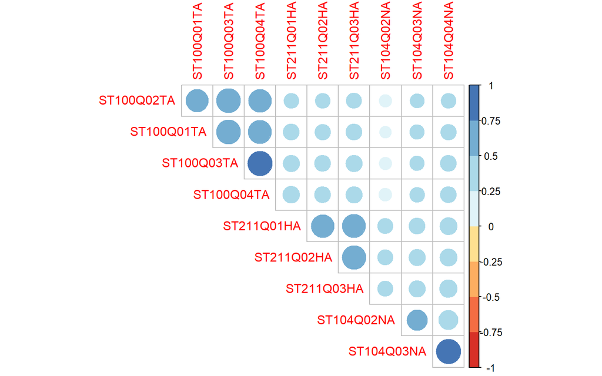

```r
#png(file="figuras/cor_policoricas/ApoioDosc.png", width=600, height=350)


corrplot(corapoio, type="upper", order="hclust",
         col=brewer.pal(n=8, name="RdYlBu"), diag = F)
```

```r
#dev.off()
```

```r
data.pcaapoio <- princomp(corapoio)
summary(data.pcaapoio)
```

```
## Importance of components:
##                           Comp.1    Comp.2     Comp.3     Comp.4     Comp.5
## Standard deviation     0.5639696 0.3918881 0.19627022 0.11556723 0.10384504
## Proportion of Variance 0.5664471 0.2735094 0.06860517 0.02378578 0.01920523
## Cumulative Proportion  0.5664471 0.8399565 0.90856165 0.93234743 0.95155267
##                            Comp.6     Comp.7     Comp.8      Comp.9
## Standard deviation     0.10087681 0.08781763 0.07209926 0.064163426
## Proportion of Variance 0.01812303 0.01373446 0.00925784 0.007332011
## Cumulative Proportion  0.96967569 0.98341015 0.99266799 1.000000000
##                                          Comp.10
## Standard deviation     0.00000000378918825137256
## Proportion of Variance 0.00000000000000002557057
## Cumulative Proportion  1.00000000000000000000000
```

```r
eigen(corapoio)
```

```
## eigen() decomposition
## $values
##  [1] 4.7489007 1.7549211 1.2232437 0.5670039 0.3652483 0.3283149 0.3127363
##  [8] 0.2773213 0.2269827 0.1953271
##
## $vectors
##             [,1]       [,2]        [,3]        [,4]         [,5]        [,6]
##  [1,] -0.3352793 -0.3509931  0.03938625  0.07474102 -0.444856032  0.55886855
##  [2,] -0.3231938 -0.3733494  0.08355228 -0.11141258  0.643975951 -0.30684003
##  [3,] -0.3550941 -0.3809945  0.04336377 -0.02647958  0.004594298 -0.02263142
##  [4,] -0.3453317 -0.3426129  0.04155829 -0.02494418 -0.213998726 -0.19317585
##  [5,] -0.3161226  0.2255633 -0.41268495 -0.01541960 -0.437642532 -0.61560328
##  [6,] -0.3165975  0.2513141 -0.41686365 -0.02153674  0.349215996  0.31000224
##  [7,] -0.3223567  0.2414361 -0.42049303  0.01616045  0.133306578  0.26864396
##  [8,] -0.2345354  0.3217665  0.36712668 -0.82266811 -0.090484040  0.07192120
##  [9,] -0.2895031  0.3340985  0.44169873  0.29349898  0.036473285 -0.01093495
## [10,] -0.3080382  0.2956166  0.37024574  0.46560757  0.028467867 -0.05617345
##               [,7]        [,8]         [,9]        [,10]
##  [1,]  0.421789814  0.10465314 -0.035278061 -0.238578572
##  [2,]  0.375426392 -0.04541777 -0.067996553 -0.283328565
##  [3,] -0.073530924 -0.02771423  0.191076798  0.826408644
##  [4,] -0.733952014 -0.01224765 -0.133069142 -0.348364440
##  [5,]  0.306037192  0.11963742 -0.009977113  0.008441709
##  [6,] -0.196452667  0.63149108  0.082931105 -0.007919806
##  [7,] -0.060090977 -0.74233966 -0.126880779  0.001089473
##  [8,]  0.006253323 -0.03102498  0.122233364 -0.024330981
##  [9,]  0.025022591  0.10939389 -0.690340630  0.180868839
## [10,] -0.022966247 -0.09473655  0.652171116 -0.158289145
```

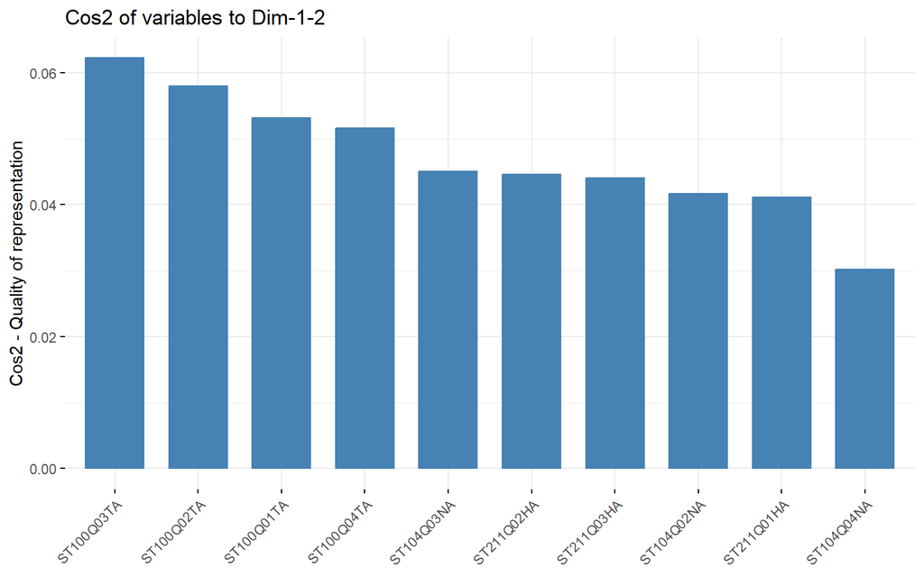

```r
#png(file="figuras/PCA/ApoioDosc1.png", width=600, height=350)

fviz_cos2(data.pcaapoio, choice = "var", axes = 1:2)
```

```r
#dev.off()
```

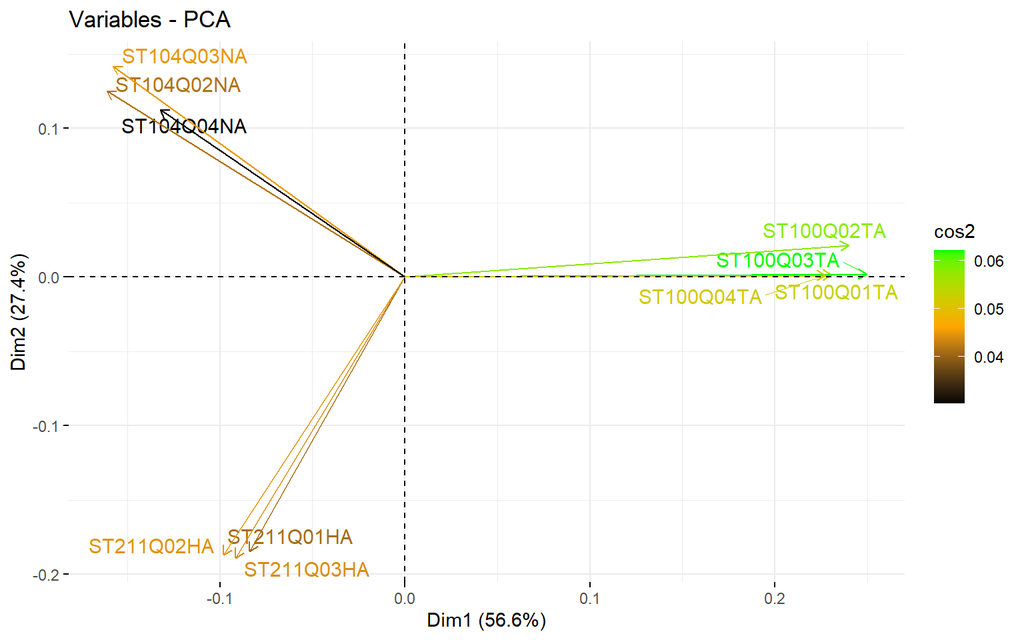

```r
#png(file="figuras/PCA/ApoioDosc2.png", width=600, height=350)

fviz_pca_var(data.pcaapoio, col.var = "cos2",
            gradient.cols = c("black", "orange", "green"),
            repel = TRUE)
```

```r
#dev.off()
```

```r
data.pcaapoio$scores
```

```
##                Comp.1      Comp.2       Comp.3       Comp.4       Comp.5
## ST100Q01TA  0.6606856  0.05241760  0.029177487  0.157424464  0.192312781
## ST100Q02TA  0.6855644  0.11943971 -0.089831997 -0.238038821 -0.094467796
## ST100Q03TA  0.7304414  0.04520124  0.018129623  0.001826821 -0.011144144
## ST100Q04TA  0.6554964  0.04651037  0.009256424  0.083515159 -0.075477892
## ST211Q01HA -0.3353360 -0.53539098 -0.013424027  0.158050031 -0.195701561
## ST211Q02HA -0.3790484 -0.54345909 -0.011358772 -0.126746688  0.098325255
## ST211Q03HA -0.3563404 -0.55183987  0.018531561 -0.047633037  0.085845634
## ST104Q02NA -0.6047180  0.46603490 -0.482441004  0.038232776  0.020828187
## ST104Q03NA -0.5716578  0.49982724  0.205029209 -0.014896386 -0.002270824
## ST104Q04NA -0.4850872  0.40125888  0.316931495 -0.011734319 -0.018249640
##                  Comp.6       Comp.7         Comp.8        Comp.9
## ST100Q01TA  0.133854209  0.025734933  0.01010317788  0.0423793684
## ST100Q02TA  0.121723610 -0.015969118  0.01809726147  0.0496071862
## ST100Q03TA -0.041092690 -0.012315185 -0.06119750082 -0.1621044490
## ST100Q04TA -0.221446712  0.007549055  0.04312045723  0.0758701454
## ST211Q01HA  0.111791699  0.030228995 -0.00007989966 -0.0053057263
## ST211Q02HA -0.064114132  0.176541989 -0.01995151994  0.0014505944
## ST211Q03HA -0.033303396 -0.205173350  0.03126300365  0.0006806534
## ST104Q02NA -0.019009855 -0.012263775 -0.03136602589 -0.0007449339
## ST104Q03NA  0.014594220  0.031555884  0.15255138067 -0.0501377807
## ST104Q04NA -0.002996953 -0.025889426 -0.14254033459  0.0483049420
##                               Comp.10
## ST100Q01TA -0.00000000000000028102520
## ST100Q02TA  0.00000000000000017694179
## ST100Q03TA  0.00000000000000021510571
## ST100Q04TA  0.00000000000000026020852
## ST211Q01HA -0.00000000000000010581813
## ST211Q02HA  0.00000000000000004163336
## ST211Q03HA -0.00000000000000025847380
## ST104Q02NA -0.00000000000000046176171
## ST104Q03NA -0.00000000000000002775558
## ST104Q04NA -0.00000000000000018041124
```

```r
modApoio = grm(apoio)
coef(modApoio)
```

```
##            Extrmt1 Extrmt2 Extrmt3 Dscrmn
## ST100Q01TA  -2.343  -1.360  -0.553  2.217
## ST100Q02TA  -2.173  -1.049  -0.119  1.859
## ST100Q03TA  -2.390  -1.331  -0.550  2.870
## ST100Q04TA  -2.088  -1.118  -0.350  2.351
## ST211Q01HA  -2.073  -0.916   1.579  1.417
## ST211Q02HA  -2.082  -0.725   1.804  1.420
## ST211Q03HA  -1.964  -0.739   1.551  1.455
## ST104Q02NA  -0.138   2.044   3.668  0.867
## ST104Q03NA  -1.126   0.606   2.163  1.163
## ST104Q04NA  -1.365   0.265   1.692  1.283
```

```r
EscApoio = factor.scores(modApoio)
```

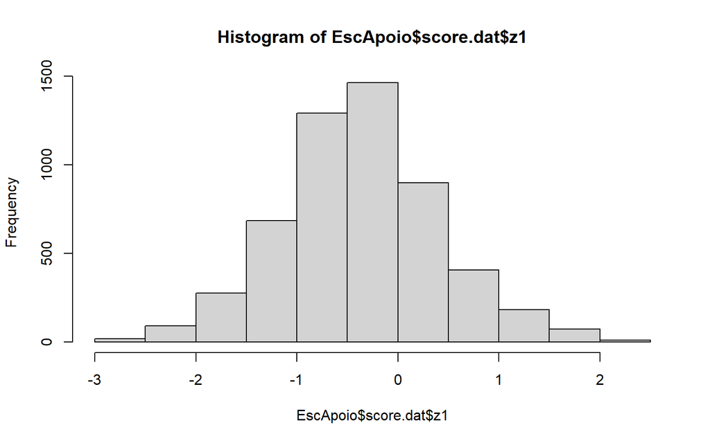

```r
hist(EscApoio$score.dat$z1)
```

```r
names(modApoio)
```

```
##  [1] "coefficients" "log.Lik"      "convergence"  "hessian"      "counts"
##  [6] "patterns"     "GH"           "max.sc"       "constrained"  "IRT.param"
## [11] "X"            "control"      "na.action"    "call"
```

```r
summary(modApoio)
```

```
##
## Call:
## grm(data = apoio)
##
## Model Summary:
##    log.Lik      AIC      BIC
##  -107554.7 215189.3 215480.4
##
## Coefficients:
## $ST100Q01TA
##          value
## Extrmt1 -2.343
## Extrmt2 -1.360
## Extrmt3 -0.553
## Dscrmn   2.217
##
## $ST100Q02TA
##          value
## Extrmt1 -2.173
## Extrmt2 -1.049
## Extrmt3 -0.119
## Dscrmn   1.859
##
## $ST100Q03TA
##          value
## Extrmt1 -2.390
## Extrmt2 -1.331
## Extrmt3 -0.550
## Dscrmn   2.870
##
## $ST100Q04TA
##          value
## Extrmt1 -2.088
## Extrmt2 -1.118
## Extrmt3 -0.350
## Dscrmn   2.351
##
## $ST211Q01HA
##          value
## Extrmt1 -2.073
```

[output cut: 33 more lines]

```
##          value
## Extrmt1 -1.365
## Extrmt2  0.265
## Extrmt3  1.692
## Dscrmn   1.283
##
##
## Integration:
## method: Gauss-Hermite
## quadrature points: 21
##
## Optimization:
## Convergence: 0
## max(|grad|): 0.31
## quasi-Newton: BFGS
```

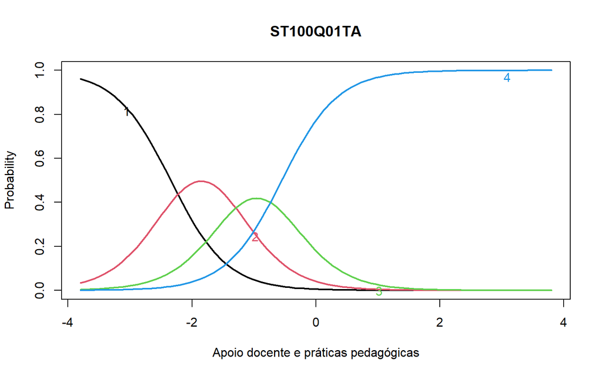

```r
#png(file="figuras/TRI/ApoioDosc_ST100Q01TA.png", width=600, height=350)
plot(modApoio, item=1,lwd = 2,main = "ST100Q01TA", xlab="Apoio docente e práticas pedagógicas",ylab="Probability")
```

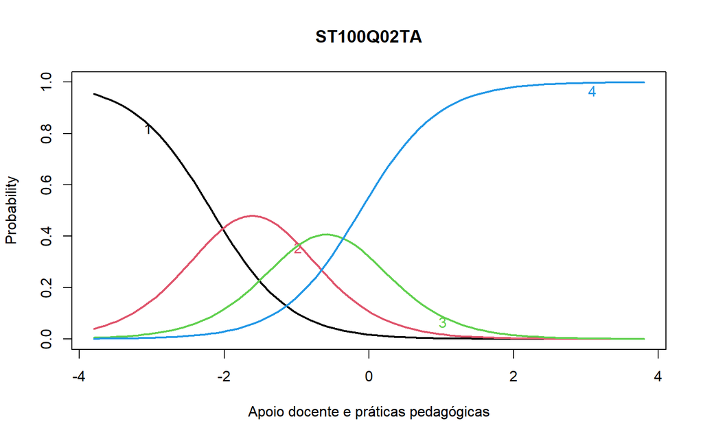

```r
#dev.off()

#png(file="figuras/TRI/ApoioDosc_ST100Q02TA.png", width=600, height=350)
plot(modApoio, item=2,lwd = 2,main = "ST100Q02TA", xlab="Apoio docente e práticas pedagógicas",ylab="Probability")
```

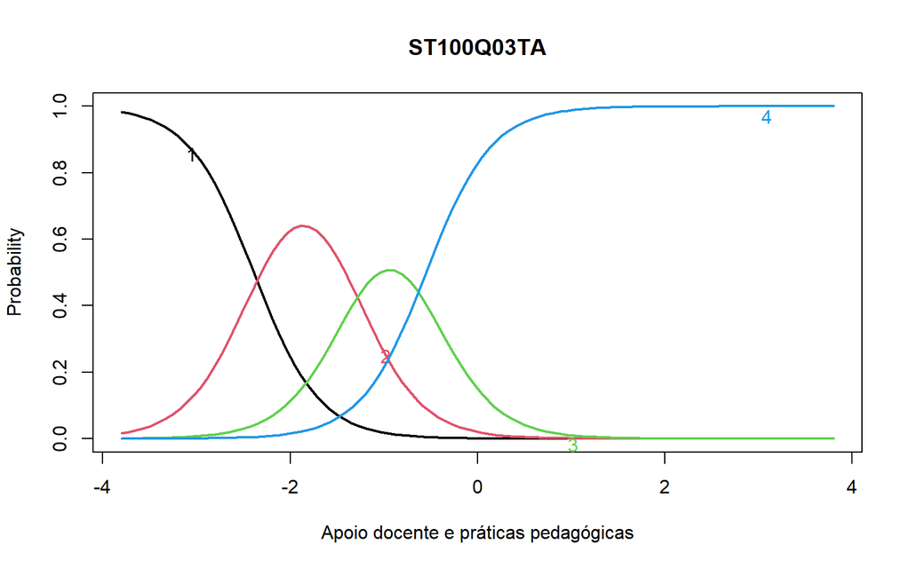

```r
#dev.off()

#png(file="figuras/TRI/ApoioDosc_ST100Q03TA.png", width=600, height=350)
plot(modApoio, item=3,lwd = 2,main = "ST100Q03TA", xlab="Apoio docente e práticas pedagógicas",ylab="Probability")
```

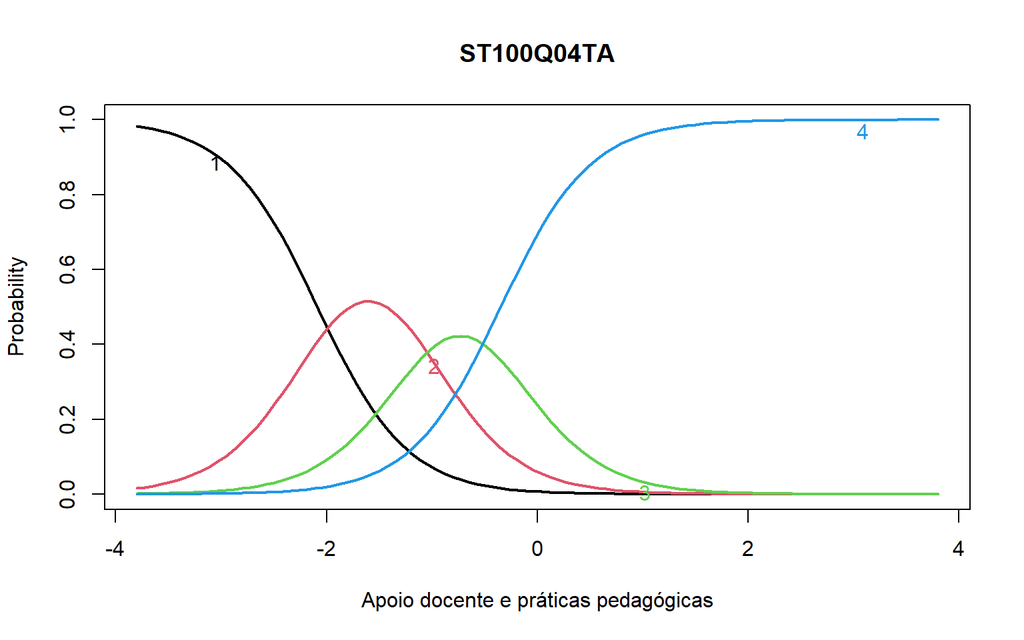

```r
#dev.off()

#png(file="figuras/TRI/ApoioDosc_ST100Q04TA.png", width=600, height=350)
plot(modApoio, item=4,lwd = 2,main = "ST100Q04TA", xlab="Apoio docente e práticas pedagógicas",ylab="Probability")
```

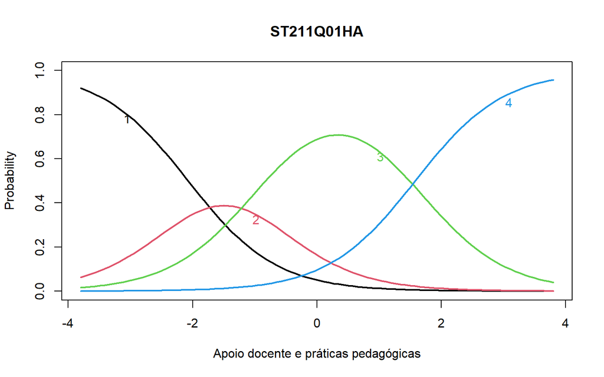

```r
#dev.off()

#png(file="figuras/TRI/ApoioDosc_ST211Q01HA.png", width=600, height=350)
plot(modApoio, item=5,lwd = 2,main = "ST211Q01HA", xlab="Apoio docente e práticas pedagógicas",ylab="Probability")
```

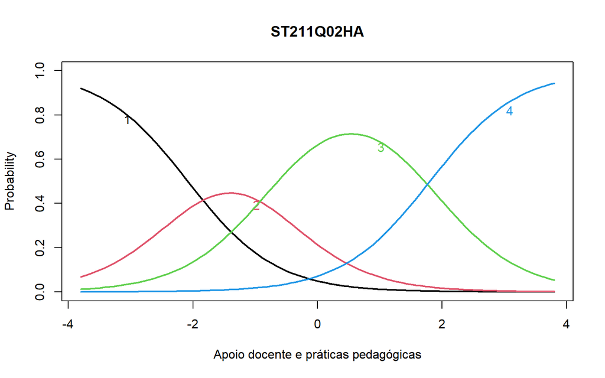

```r
#dev.off()

#png(file="figuras/TRI/ApoioDosc_ST211Q02HA.png", width=600, height=350)
plot(modApoio, item=6,lwd = 2,main = "ST211Q02HA", xlab="Apoio docente e práticas pedagógicas",ylab="Probability")
```

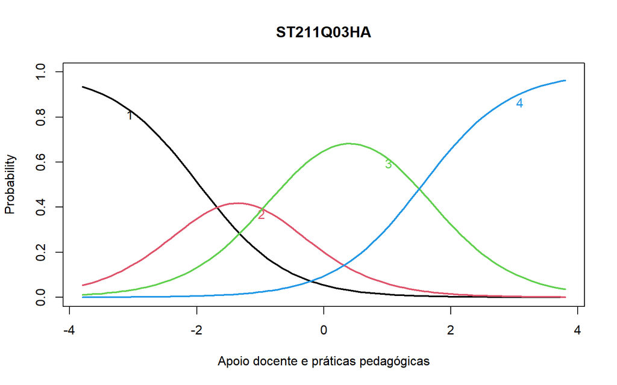

```r
#dev.off()

#png(file="figuras/TRI/ApoioDosc_ST211Q03HA.png", width=600, height=350)
plot(modApoio, item=7,lwd = 2,main = "ST211Q03HA", xlab="Apoio docente e práticas pedagógicas",ylab="Probability")
```

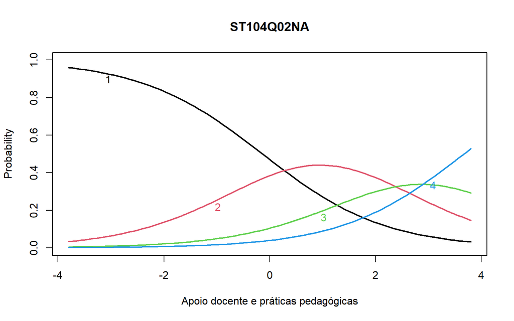

```r
#dev.off()

#png(file="figuras/TRI/ApoioDosc_ST104Q02NA.png", width=600, height=350)
plot(modApoio, item=8,lwd = 2,main = "ST104Q02NA", xlab="Apoio docente e práticas pedagógicas",ylab="Probability")
```

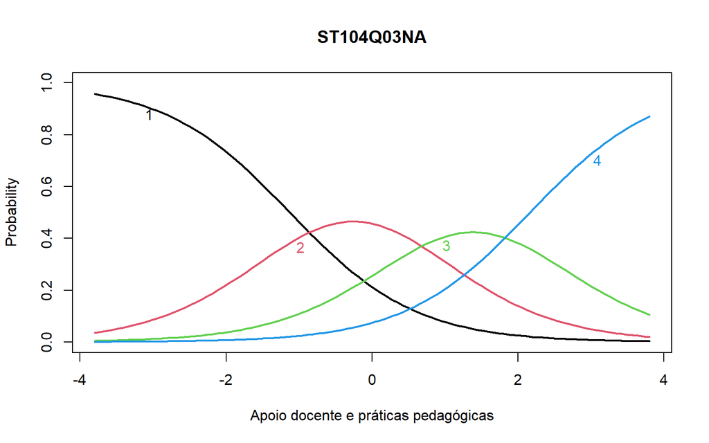

```r
#dev.off()

#png(file="figuras/TRI/ApoioDosc_ST104Q03NA.png", width=600, height=350)
plot(modApoio, item=9,lwd = 2,main = "ST104Q03NA", xlab="Apoio docente e práticas pedagógicas",ylab="Probability")
```

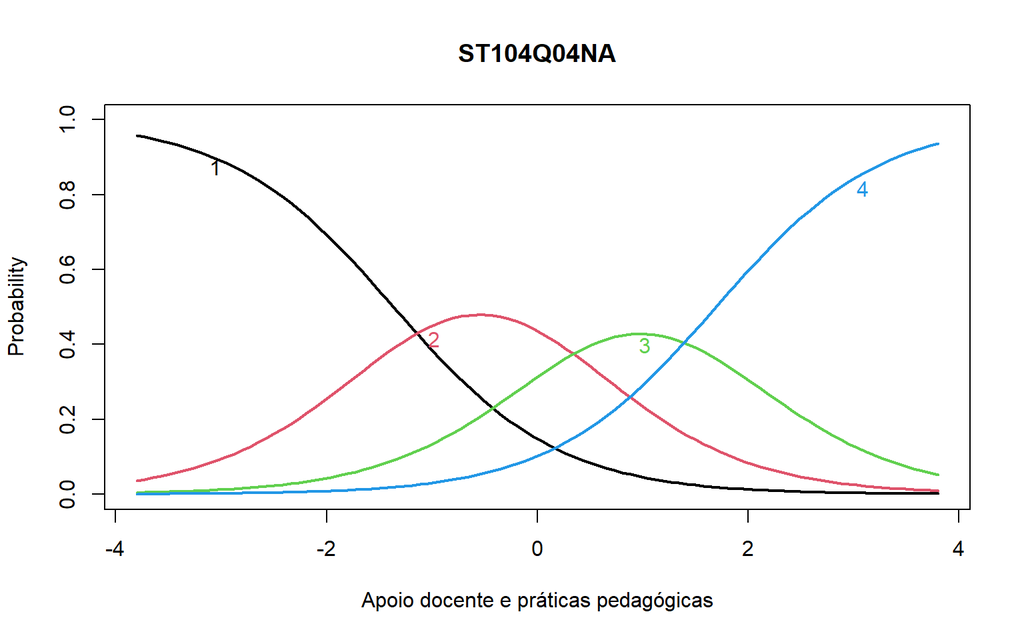

```r
#dev.off()

#png(file="figuras/TRI/ApoioDosc_ST104Q04NA.png", width=600, height=350)
plot(modApoio, item=10,lwd = 2,main = "ST104Q04NA", xlab="Apoio docente e práticas pedagógicas",ylab="Probability")
```

```r
#dev.off()
```

O codigo abaixo inclui a variavel de Apoio docente e práticas pedagógicas no banco de dados final, df_pisa.

```r
df_pisa = EscApoio$score.dat %>%
  dplyr::select(-Obs, -Exp, -se.z1) %>%
  mutate_at(vars(starts_with("ST")), factor) %>%
  mutate_at(vars(starts_with("PA")), factor) %>%
  mutate_at(vars(starts_with("SC")), factor)%>%
  rename("Apoio docente" = z1) %>%
  mutate(Apoio_docente_Z = scale(`Apoio docente`)[,1]) %>%
  right_join(df_pisa)
```

## Comportamento do professor e aprendizagem dos alunos

```r
comprof = df_pisa %>%
  dplyr::select(SC061Q06TA,SC061Q07TA,SC061Q08TA,SC061Q09TA,SC061Q10TA)

corcomprof = hetcor(comprof)

#Matrix de correlacao policorica do comportamento do prof e aprendizagem dos alunos
corcomprof = corcomprof$correlations
```

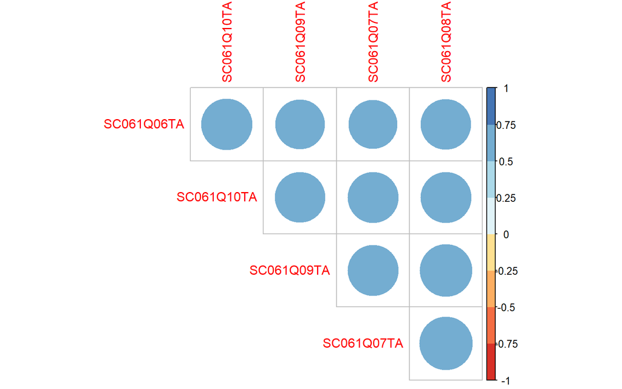

```r
#png(file="figuras/cor_policoricas/CompProf.png", width=600, height=350)


corrplot(corcomprof, type="upper", order="hclust",
         col=brewer.pal(n=8, name="RdYlBu"), diag = F)
```

```r
#dev.off()
```

```r
data.pcacomprof <- princomp(corcomprof)
summary(data.pcacomprof)
```

```
## Importance of components:
##                           Comp.1    Comp.2    Comp.3    Comp.4
## Standard deviation     0.2200696 0.1822274 0.1740948 0.1488866
## Proportion of Variance 0.3611162 0.2476022 0.2259948 0.1652869
## Cumulative Proportion  0.3611162 0.6087184 0.8347131 1.0000000
##                                          Comp.5
## Standard deviation     0.0000000079025340957926
## Proportion of Variance 0.0000000000000004656501
## Cumulative Proportion  1.0000000000000000000000
```

```r
eigen(corcomprof)
```

```
## eigen() decomposition
## $values
## [1] 3.3825375 0.4898306 0.4074417 0.3892195 0.3309707
##
## $vectors
##            [,1]       [,2]        [,3]       [,4]       [,5]
## [1,] -0.4339982 -0.6975742 -0.15043420  0.5111651 -0.2027700
## [2,] -0.4482902  0.4560196  0.52135657  0.1830891 -0.5345537
## [3,] -0.4591809  0.3388456 -0.05475408  0.3502651  0.7407111
## [4,] -0.4474879  0.2376576 -0.73051519 -0.3748682 -0.2628590
## [5,] -0.4467538 -0.3662499  0.41098227 -0.6648133  0.2353485
```

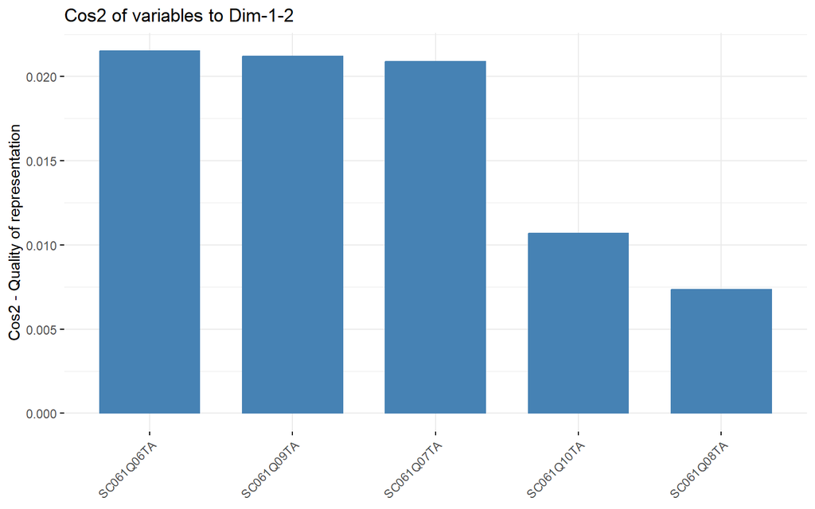

```r
#png(file="figuras/PCA/CompProf1.png", width=600, height=350)

fviz_cos2(data.pcacomprof , choice = "var", axes = 1:2)
```

```r
#dev.off()
```

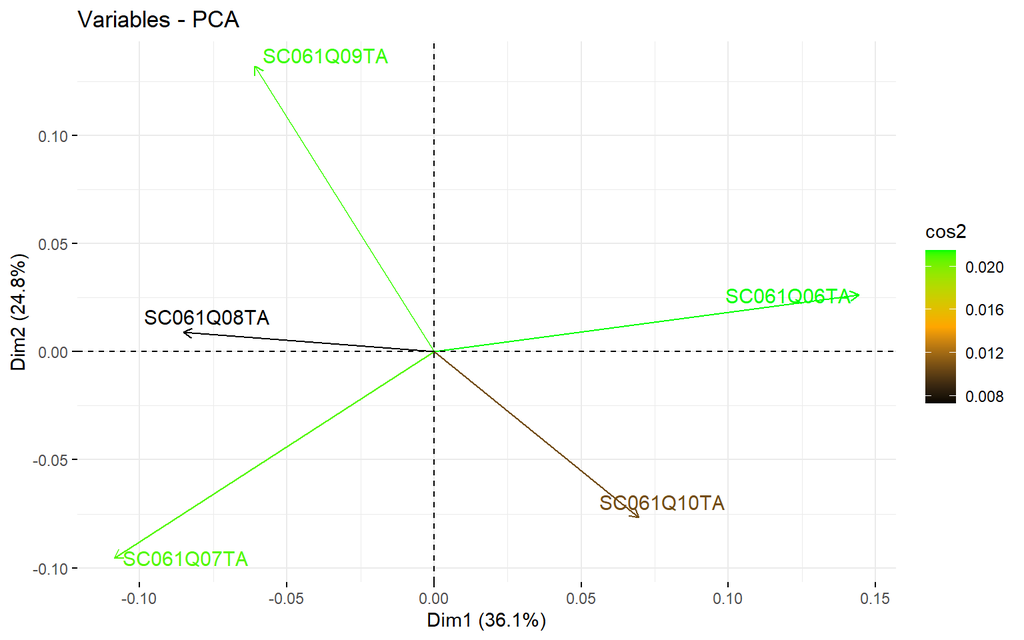

```r
#png(file="figuras/PCA/CompProf2.png", width=600, height=350)

fviz_pca_var(data.pcacomprof, col.var = "cos2",
            gradient.cols = c("black", "orange", "green"),
            repel = TRUE)
```

```r
#dev.off()
```

```r
data.pcacomprof$scores
```

```
##                Comp.1      Comp.2      Comp.3      Comp.4
## SC061Q06TA  0.3426505  0.06091191  0.19790903  0.06169359
## SC061Q07TA -0.2245516 -0.21122249  0.07341271  0.17850816
## SC061Q08TA -0.1738709  0.02185632  0.13460150 -0.24751204
## SC061Q09TA -0.1179460  0.29765919 -0.14602687  0.08694972
## SC061Q10TA  0.1737180 -0.16920492 -0.25989637 -0.07963944
##                                Comp.5
## SC061Q06TA  0.00000000000000004857226
## SC061Q07TA -0.00000000000000014571677
## SC061Q08TA -0.00000000000000004857226
## SC061Q09TA -0.00000000000000007632783
## SC061Q10TA -0.00000000000000013877788
```

```r
modComprof = grm(comprof)
coef(modComprof)
```

```
##            Extrmt1 Extrmt2 Extrmt3 Dscrmn
## SC061Q06TA  -1.853  -0.096   1.645  1.944
## SC061Q07TA  -1.721  -0.386   0.929  2.312
## SC061Q08TA  -1.557  -0.302   1.100  2.550
## SC061Q09TA  -2.513  -1.032   0.560  2.268
## SC061Q10TA  -1.758  -0.589   0.732  2.173
```

```r
EscComprof = factor.scores(modComprof)
```

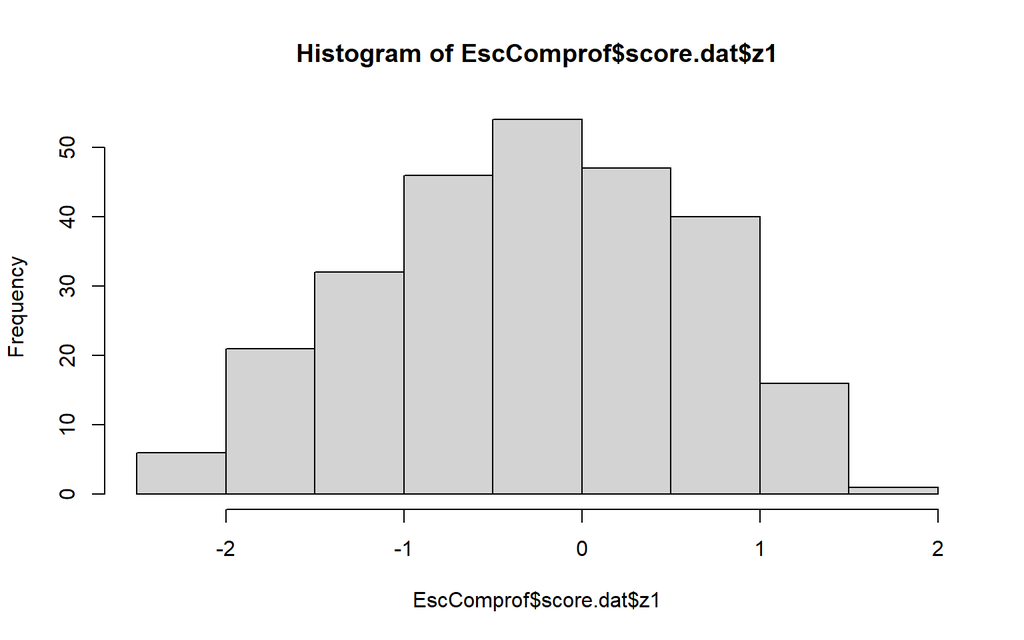

```r
hist(EscComprof$score.dat$z1)
```

```r
names(modComprof)
```

```
##  [1] "coefficients" "log.Lik"      "convergence"  "hessian"      "counts"
##  [6] "patterns"     "GH"           "max.sc"       "constrained"  "IRT.param"
## [11] "X"            "control"      "na.action"    "call"
```

```r
summary(modComprof)
```

```
##
## Call:
## grm(data = comprof)
##
## Model Summary:
##    log.Lik      AIC      BIC
##  -55366.68 110773.4 110918.9
##
## Coefficients:
## $SC061Q06TA
##          value
## Extrmt1 -1.853
## Extrmt2 -0.096
## Extrmt3  1.645
## Dscrmn   1.944
##
## $SC061Q07TA
##          value
## Extrmt1 -1.721
## Extrmt2 -0.386
## Extrmt3  0.929
## Dscrmn   2.312
##
## $SC061Q08TA
##          value
## Extrmt1 -1.557
## Extrmt2 -0.302
## Extrmt3  1.100
## Dscrmn   2.550
##
## $SC061Q09TA
##          value
## Extrmt1 -2.513
## Extrmt2 -1.032
## Extrmt3  0.560
## Dscrmn   2.268
##
## $SC061Q10TA
##          value
## Extrmt1 -1.758
## Extrmt2 -0.589
## Extrmt3  0.732
## Dscrmn   2.173
##
##
## Integration:
## method: Gauss-Hermite
## quadrature points: 21
##
## Optimization:
## Convergence: 0
## max(|grad|): 0.25
## quasi-Newton: BFGS
```

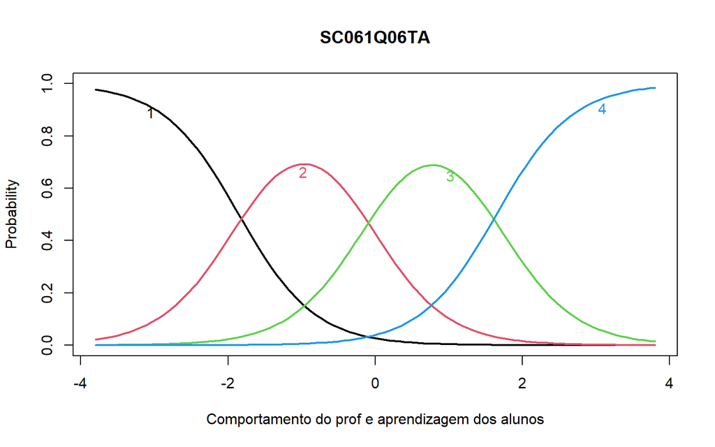

```r
#png(file="figuras/TRI/CompProf_SC061Q06TA.png", width=600, height=350)
plot(modComprof, item=1,lwd = 2,main = "SC061Q06TA", xlab="Comportamento do prof e aprendizagem dos alunos",ylab="Probability")
```

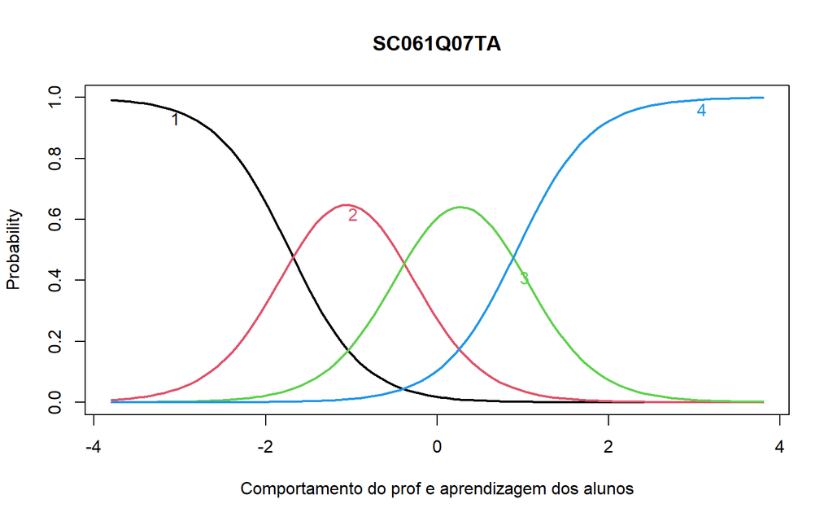

```r
#dev.off()

#png(file="figuras/TRI/CompProf_SC061Q07TA.png", width=600, height=350)
plot(modComprof, item=2,lwd = 2,main = "SC061Q07TA", xlab="Comportamento do prof e aprendizagem dos alunos",ylab="Probability")
```